# Example: GDP Per Capita in Asia

Chris Callaghan

Last Edited On: 2021-08-12

# 1 Background

This document explores the changes in GDP per capita across the Asian continent from 2000 to 2019.

# 2 About the data

This analysis leverages data from [The World Bank World Development Indicators](https://finances.worldbank.org/Procurement/Major-Contract-Awards/kdui-wcs3) and [Natural Earth](https://www.naturalearthdata.com/).

## 2.1 The World Bank World Development Indicators

These can be accessed through The World Bank Development Indicators [site](https://databank.worldbank.org/source/world-development-indicators#), which allows the user to download individual indicators. This analysis leverages data for:

- GDP per capita, (current US$)

The data used includes all available countries and observations from 2000 to 2020.

## 2.2 Natural Earth

Natural Earth is a public domain map data set. In this analysis the data was accessed via the R package [**{rnaturalearth}**](https://cran.r-project.org/web/packages/rnaturalearth/README.html).

# 3 Data Carpentry

```r
install.packages("tidyverse")
install.packages("rnaturalearth")
install.packages("rnaturalearthdata")
```

Before getting started, load the libraries required:

```r
library(tidyverse)
library(rnaturalearth)
library(rnaturalearthdata)
```

## 3.1 Getting Spatial Data

```r
# For more information: ?ne_countries
spatial_data <- ne_countries(
  scale = "medium",
  continent = "Asia",
  returnclass = "sf"
) %>%
  janitor::clean_names()
```

Take a look at the data:

```r
str(spatial_data)
```

[output not shown]

## 3.2 World Bank Development Indicators

The data was downloaded from The World Bank site and stored as comma-delimited file. First read it:

```r
file_path <- "data/wb_gdppc_2000to2020.csv"
(gdp <- read_csv(file = here::here(file_path)) %>%
  janitor::clean_names())
```

```
## # A tibble: 271 × 25
##    country_name  country_code series_name  series_code x2000_yr2000 x2001_yr2001
##    <chr>         <chr>        <chr>        <chr>       <chr>        <chr>
##  1 Afghanistan   AFG          GDP per cap… NY.GDP.PCA… ..           ..
##  2 Albania       ALB          GDP per cap… NY.GDP.PCA… 1126.683317… 1281.659393…
##  3 Algeria       DZA          GDP per cap… NY.GDP.PCA… 1765.026718… 1740.607066…
##  4 American Sam… ASM          GDP per cap… NY.GDP.PCA… ..           ..
##  5 Andorra       AND          GDP per cap… NY.GDP.PCA… 21854.24680… 22970.51221…
##  6 Angola        AGO          GDP per cap… NY.GDP.PCA… 556.8386316… 527.3335285…
##  7 Antigua and … ATG          GDP per cap… NY.GDP.PCA… 10872.29295… 10367.31960…
##  8 Argentina     ARG          GDP per cap… NY.GDP.PCA… 7708.099114… 7208.373113…
##  9 Armenia       ARM          GDP per cap… NY.GDP.PCA… 622.7409229… 694.4234553…
## 10 Aruba         ABW          GDP per cap… NY.GDP.PCA… 20617.75046… 20670.36700…
## # … with 261 more rows, and 19 more variables: x2002_yr2002 <chr>,
## #   x2003_yr2003 <chr>, x2004_yr2004 <chr>, x2005_yr2005 <chr>,
## #   x2006_yr2006 <chr>, x2007_yr2007 <chr>, x2008_yr2008 <chr>,
## #   x2009_yr2009 <chr>, x2010_yr2010 <chr>, x2011_yr2011 <chr>,
## #   x2012_yr2012 <chr>, x2013_yr2013 <chr>, x2014_yr2014 <chr>,
## #   x2015_yr2015 <chr>, x2016_yr2016 <chr>, x2017_yr2017 <chr>,
## #   x2018_yr2018 <chr>, x2019_yr2019 <chr>, x2020_yr2020 <chr>
```

In order to use the data it will need to be cleaned. Specifically:

```r
gdp <- gdp %>%
  # Remove extra variables:
  select(-series_code) %>%
  # Pivot longer to clean the data
  pivot_longer(-c("country_name", "country_code", "series_name"),
               names_to = "year", values_to = "value") %>%
  # Mutate variables to clean data
  mutate(
    year  = str_replace(year, ".*(yr)", ""),
    year  = as.numeric(year),
    value = ifelse(value == "..", NA, value),
    value = as.numeric(value)
    )
```

# 4 Analysis

## 4.1 Temporal Analysis

The figure below, presents the trends in GDP per capita across Asia from 2000 to 2019. The black line represents the average GDP per capita for all nations in Asia for a given year. The blue line is the smoothed line to aid in the process of seeing patterns, the grey area surrounding this line is the standard error. Overall, it appears that GDP per capita plateaued around 2013 and growth has remain constant since.

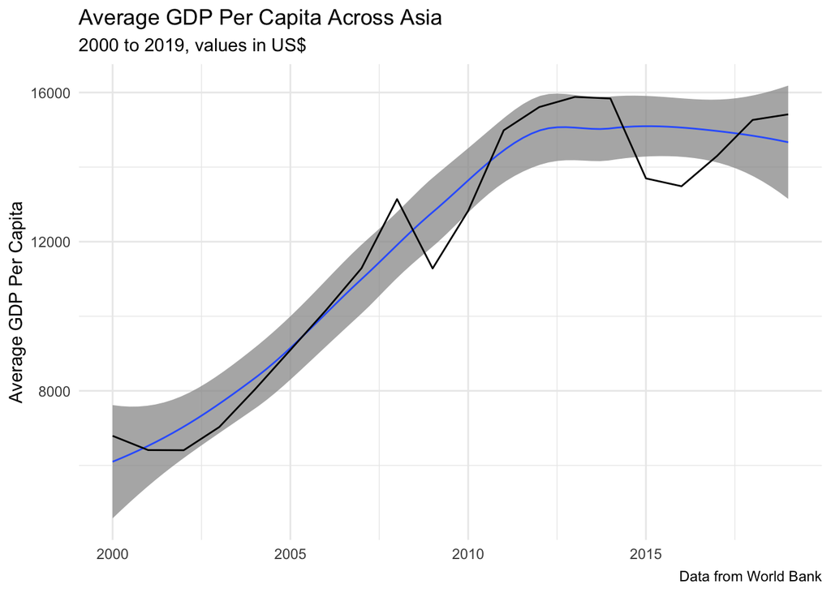

GDP Per Capita Across Asia

```r
spatial_data %>%
  select(geometry, iso_a3, name_sort) %>%
  left_join(gdp, by = c("iso_a3" = "country_code")) %>%
  sf::st_set_geometry(NULL) %>%
  group_by(series_name, year) %>%
  summarise(value = mean(value, na.rm = TRUE)) %>%
  filter(!is.na(series_name),
         year < 2020) %>%
  ggplot() +
  geom_smooth(aes(x = year, y = value), se = TRUE, alpha = 0.75, lwd = 0.5) +
  geom_line(aes(x = year, y = value), lwd = 0.5, color = "black") +
  scale_color_brewer(palette = "Set2") +
  theme_minimal() +
  labs(y = "Average GDP Per Capita", x = NULL, colour = NULL,
       title = "Average GDP Per Capita Across Asia",
       subtitle = "2000 to 2019, values in US$",
       caption = "Data from World Bank") +
  theme(legend.position = "top")
```

## 4.2 Spatial Analysis

The map below suggests that Japan and the UAE enjoy a higher average GDP per capita for period of time included in the data.

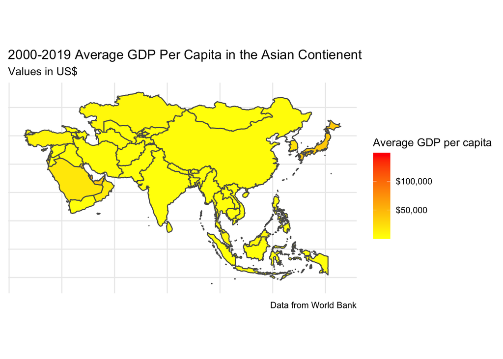

GDP Per Capita Across Asia

```r
gdp %>%
  group_by(country_name, country_code) %>%
  summarise(avg_gdppc = mean(value, na.rm = TRUE)) %>%
  left_join(spatial_data, by = c("country_code" = "iso_a3")) %>%
  sf::st_as_sf() %>%
  ggplot() +
  geom_sf(aes(fill = avg_gdppc)) +
  scale_fill_continuous(low = "yellow", high = "red", na.value = NA,
                        name = "Average GDP per capita",
                        label = scales::dollar) +
  theme_minimal() +
  labs(title = "2000-2019 Average GDP Per Capita in the Asian Contienent",
       subtitle = "Values in US$",
       caption = "Data from World Bank") +
  theme(legend.position = "right",
        axis.text  = element_blank(),
        axis.ticks = element_blank())
```